# Revisión de la clasificación de delitos utilizando diccionarios

Alejandro Sánchez P.

2023-07-14

## Objetivo

El objetivo principal es desarrollar un sistema automatizado que pueda revisar y al mismo tiempo clasificar delitos basándose en descripciones textuales. Para lograr esto, utilizaremos diccionarios y la distancia de Levenshtein como una medida de similitud entre las descripciones de los delitos y las categorías predefinidas.

## Metodología

Este enfoque se basa en el uso de diccionarios temáticos que contienen palabras y frases clave asociadas a diferentes categorías de delitos. Estos diccionarios se construyen a partir de información recopilada de fuentes confiables y actualizadas, así como informes policiales y jurisprudencia relevante.

La distancia de Levenshtein, una medida de la diferencia entre dos cadenas de caracteres, se utilizará para corregir posibles errores ortográficos en la descripción y poder realizar una lematización pertinente. Para identificar la similitud entre una descripción de delito dada y las palabras clave contenidas en los diccionarios temáticos se consideran descripciones similares, conocidas como sinoninmias contextuales. Esto es de particular utilidad porque un mismo delito puede identificarse por los informantes de múltiples formas en una misma localidad.

## Implementación

Para implementar este sistema, se emplean técnicas de procesamiento del lenguaje natural y aprendizaje automático. Primero, se procesan y limpian los textos de las descripciones de los delitos para eliminar ruido y palabras irrelevantes. Luego, se usa la distancia de Levenshtein para comparar cada descripción con las palabras clave en los diccionarios temáticos.

Además, *a posteriori* se busca entrenar un modelo de aprendizaje automático utilizando algoritmos de clasificación como la clasificación de vectores de soporte (SVM) o la clasificación Naïve Bayes para mejorar la precisión y eficiencia de nuestro sistema de clasificación de delitos.

Se comienza presentando la clasificación de delitos de acuerdo con claves preestablecidas. En este caso se tienen 15 delitos que engloban, hasta cierto punto, aquellos con una mayor prevalencia.

```
##  [1] "Robo de vehículo"         "Robo parcial de vehículo"
##  [3] "Vandalismo"               "Robo a casa habitación"
##  [5] "Robo a transeunte"        "Otros robos"
##  [7] "Fraude bancario"          "Fraude al consumidor"
##  [9] "Extorsión"                "Amenazas"
## [11] "Lesiones"                 "Secuestro"
## [13] "Delitos sexuales"         "Violación sexual"
## [15] "Homicidio"
```

Por otra parte, se tiene el *dataset* proveniente de una primera clasificación realizada por el área conceptual, por los encargados del levantamiento de la información o algún equipo especializado. Este conjunto de datos se presenta como una tabla con dos columnas.La primera indica la clave asignada por el revisor y en segundo lugar está la descripción textual declarada por el informante. Esta primera asignación de la clave ID_DEL se ha llevado a cabo de acuerdo con los criterios del equipo revisor.

```
##    ID_DEL                                              DEL_X
## 1       3                       rayas con un clavo a mi auto
## 2       2                        robo de batería de mi coche
## 3       1                                    robo de mi auto
## 4       4                   entraron a robar al departamento
## 5       9     amenazas por vender frituras cerca de una casa
## 6       7                                clonaron mi tarjeta
## 7       7          me vendieron un seguro bancario sin saber
## 8       5                                   asalto en pecera
## 9       6        robaron el cargador de mi lap en la oficina
## 10      6                 robaron mi casillero en la empresa
## 11      8     estafa en línea no recibí el producto esperado
## 12     11                  cortada por discusión con vecinos
## 13     12                       levantón para exigir rescate
## 14     13                                   manoseo en metro
```

[output cut: 24 more lines]

*Grosso modo* el proceso implica la lematización de las descripciones y hace uso de un diccionario construido con la idea de la sinomimia contextual de los delitos/descripciones que se indican en el catálogo inicial. Esto depende en gran medida de la correcta creación del diccionario y una cantidad robusta de descripciones.

De esta manera, al llevar a cabo la revisión usando como insumo el *dataset* mostrado arriba se tiene el siguiente *dataframe* que conjunta la tabla inicial y la parte correspondiente a la revisión.

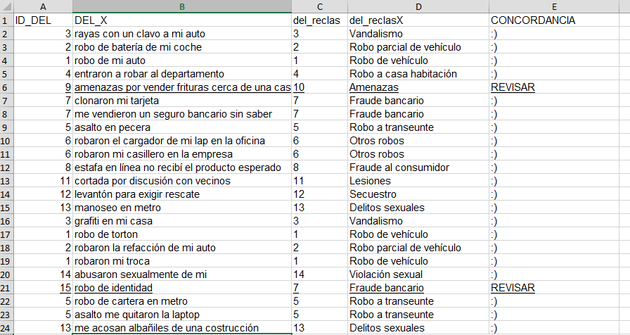

Imagen 1.

Esto último puede observarse en la siguiente imagen en la que hay códigos mal asigandos y delitos no contemplados en el diccionario inicial.

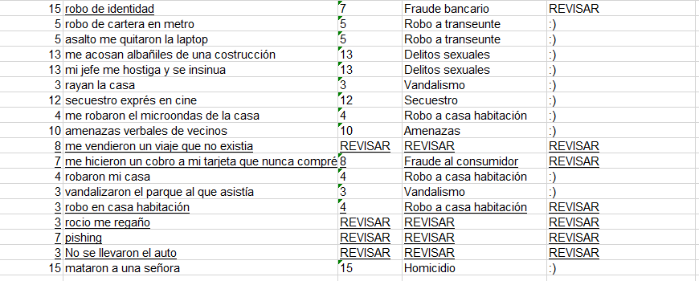

Imagen 2.

Los casos no contemplados se incluyen conforme sea su aparición para robustecer el diccionario base. Esta parte no se ha comparado con alguna otra herramienta pues se requieren insumos para darle seguimiento.

## Utilidades y beneficios

Al usar este tipo de revisión se tienen identificadas ventajas:

1. Mejora de la eficiencia en la clasificación de delitos ya que el programa no solo revisa, sino que clasifica.
2. Ayuda en la identificación rápida de patrones y tendencias en los delitos, lo que puede ayudar a la toma de decisiones informadas y a la des-ambigüación de delitos.
3. Apoyo a la verificación de inconsistencias en la clasificación inicial.

Inconvenientes principales:

1. Requiere de diccionarios robustos.
2. El proceso de lematización puede ser tardado dependiendo del número de casos incluidos en el diccionario.
3. La revisión depende de una buena escritura o estructura gramatical.